# 重賞レース予測レポート【レース終了】

作成日時: 2026/05/03 21:24:23

☞ [マニュアル(pdf)](https://ryutoro-galois.github.io/keiba-predictor/manual/manual.pdf)

☞ 過去6年の同一レース結果: [2025年](https://ryutoro-galois.github.io/keiba-predictor/report/PredResult_2025y_raceDate_20250503_20250504.html), [2024年](https://ryutoro-galois.github.io/keiba-predictor/report/PredResult_2024y_raceDate_20240427_20240428.html), [2023年](https://ryutoro-galois.github.io/keiba-predictor/report/PredResult_2023y_raceDate_20230429_20230430.html), [2022年](https://ryutoro-galois.github.io/keiba-predictor/report/PredResult_2022y_raceDate_20220507_20220508.html), [2021年](https://ryutoro-galois.github.io/keiba-predictor/report/PredResult_2021y_raceDate_20210501_20210502.html), [2020年](https://ryutoro-galois.github.io/keiba-predictor/report/PredResult_2020y_raceDate_20200502_20200503.html)

☞ 過去4週間の別レース結果: [1週前(4/25-26)](https://ryutoro-galois.github.io/keiba-predictor/report/PredResult_2026y_raceDate_20260425_20260426.html), [2週前(4/18-19)](https://ryutoro-galois.github.io/keiba-predictor/report/PredResult_2026y_raceDate_20260418_20260419.html), [3週前(4/11-12)](https://ryutoro-galois.github.io/keiba-predictor/report/PredResult_2026y_raceDate_20260411_20260412.html), [4週前(4/4-5)](https://ryutoro-galois.github.io/keiba-predictor/report/PredResult_2026y_raceDate_20260404_20260405.html)

☞ netkeiba: [京王杯スプリングC(GⅡ)](https://race.netkeiba.com/race/result.html?race_id=202605020311&rf=race_submenu), [ユニコーンステークス(GⅢ)](https://race.netkeiba.com/race/result.html?race_id=202608030311&rf=race_submenu), [天皇賞(春)(GⅠ)](https://race.netkeiba.com/race/result.html?race_id=202608030411&rf=race_submenu)

☞ レース結果(csv): [5/2-3](https://ryutoro-galois.github.io/keiba-predictor/csv/race_result_20260502_20260503.csv)

## 【レース結果(1)】人気と着順の関係

### 【京王杯スプリングC(2026/05/02(土))】

【京王杯スプリングC(GⅡ)】  
2026/05/02(土), 05_東京, 芝左1400m

[interactive chart not shown]

### 【ユニコーンステークス(2026/05/02(土))】

[interactive chart not shown]

### 【天皇賞(春)(2026/05/03(日))】

【天皇賞(春)(GⅠ)】  
2026/05/03(日), 08_京都, 芝右外3200m

[interactive chart not shown]

## 【レース結果(2)】コーナー通過順位

### 【京王杯スプリングC(2026/05/02(土))】

【京王杯スプリングC(GⅡ)】  
2026/05/02(土), 05_東京, 芝左1400m

[interactive chart not shown]

### 【ユニコーンステークス(2026/05/02(土))】

[interactive chart not shown]

### 【天皇賞(春)(2026/05/03(日))】

【天皇賞(春)(GⅠ)】  
2026/05/03(日), 08_京都, 芝右外3200m

[interactive chart not shown]

## 0. 推し馬予測 (AI予測)

### 【京王杯スプリングC(GⅡ) 2026/05/02(土)】

- 本命(◎): 1-3着内確率(勝負強さ)が1位の馬
- 対抗(◯): 1-3着内確率が2-N位(20%程度以上)の中で予測タイムが最も速い馬
- 3番手(▲): 1-3着内確率が2-N位(20%程度以上)のでダークホース確率が最も高い馬
- 穴: ダークホース確率が上位1-M位(40%程度以上)の中で1-3着内確率が最も高い馬

| 推し馬 | 枠番 | 馬番 | 人気 | オッズ | 馬名 | 騎手 | 調教師 | 予測タイム(sec) | 1_順位 | 1-3着内確率(%) | 2_順位 | ﾀﾞｰｸﾎｰｽ確率(%) | 3_順位 |
| --- | --- | --- | --- | --- | --- | --- | --- | --- | --- | --- | --- | --- | --- |
| 本命(◎) | 1 | 2 | 2 | 4.4 | ダノンセンチュリー | Ｄ．レーン | 萩原清 | 80.9 | 8 | 39.7 | 1 | 0.5 | 16 |
| 対抗(◯) | 8 | 16 | 3 | 5.4 | ワールズエンド | 津村明秀 | 池添学 | 79.9 | 2 | 31.3 | 2 | 0.5 | 17 |
| 3番手(▲) | 5 | 10 | 6 | 15.1 | キープカルム | 荻野極 | 中竹和也 | 83.3 | 11 | 27.9 | 3 | 1.3 | 10 |
| 穴 | 7 | 15 | 17 | 198.5 | レイベリング | 石橋脩 | 鹿戸雄一 | 86.2 | 12 | 12.2 | 9 | 52.3 | 1 |

### 【ユニコーンステークス(GⅢ) 2026/05/02(土)】

- 本命(◎): 1-3着内確率(勝負強さ)が1位の馬
- 対抗(◯): 1-3着内確率が2-N位(20%程度以上)の中で予測タイムが最も速い馬
- 3番手(▲): 1-3着内確率が2-N位(20%程度以上)のでダークホース確率が最も高い馬
- 穴: ダークホース確率が上位1-M位(40%程度以上)の中で1-3着内確率が最も高い馬

| 推し馬 | 枠番 | 馬番 | 人気 | オッズ | 馬名 | 騎手 | 調教師 | 予測タイム(sec) | 1_順位 | 1-3着内確率(%) | 2_順位 | ﾀﾞｰｸﾎｰｽ確率(%) | 3_順位 |
| --- | --- | --- | --- | --- | --- | --- | --- | --- | --- | --- | --- | --- | --- |
| 本命(◎) | 4 | 4 | 2 | 2.8 | シルバーレシオ | 岩田望来 | 野中賢二 | 103.1 | 6 | 49.9 | 1 | 0.4 | 11 |
| 対抗(◯) | 2 | 2 | 5 | 10.4 | ケイアイアギト | 鮫島克駿 | 加藤征弘 | 96.2 | 2 | 22.6 | 3 | 1.9 | 7 |
| 3番手(▲) | 7 | 9 | 3 | 8.0 | ソルチェリア | 幸英明 | 大根田裕之 | 103.4 | 7 | 27.4 | 2 | 1.0 | 8 |
| 穴 | 5 | 6 | 10 | 119.7 | ヴィエントデコラ | 浜中俊 | 寺島良 | 103.5 | 8 | 5.4 | 7 | 40.7 | 1 |

### 【天皇賞(春)(GⅠ) 2026/05/03(日)】

- 本命(◎): 1-3着内確率(勝負強さ)が1位の馬
- 対抗(◯): 1-3着内確率が2-N位(20%程度以上)の中で予測タイムが最も速い馬
- 3番手(▲): 1-3着内確率が2-N位(20%程度以上)のでダークホース確率が最も高い馬
- 穴: ダークホース確率が上位1-M位(40%程度以上)の中で1-3着内確率が最も高い馬

| 推し馬 | 枠番 | 馬番 | 人気 | オッズ | 馬名 | 騎手 | 調教師 | 予測タイム(sec) | 1_順位 | 1-3着内確率(%) | 2_順位 | ﾀﾞｰｸﾎｰｽ確率(%) | 3_順位 |
| --- | --- | --- | --- | --- | --- | --- | --- | --- | --- | --- | --- | --- | --- |
| 本命(◎) | 4 | 7 | 1 | 1.8 | クロワデュノール | 北村友一 | 斉藤崇史 | 192.5 | 1 | 42.0 | 1 | 0.6 | 13 |
| 対抗(◯) | 2 | 3 | 2 | 3.2 | アドマイヤテラ | 武豊 | 友道康夫 | 195.5 | 2 | 21.1 | 4 | 0.5 | 15 |
| 3番手(▲) | 5 | 8 | 5 | 27.5 | シンエンペラー | 岩田望来 | 矢作芳人 | 199.7 | 8 | 28.2 | 3 | 1.4 | 9 |
| 穴 | 5 | 9 | 15 | 213.2 | プレシャスデイ | 吉村誠之助 | 伊坂重信 | 202.3 | 12 | 8.8 | 10 | 55.8 | 1 |

## 1. 予測チャート (タイム/勝負強さ)

### 【京王杯スプリングC(GⅡ)】

2026/05/02(土), 05_東京, 芝左1400m

[interactive chart not shown]

### 【ユニコーンステークス(GⅢ)】

[interactive chart not shown]

### 【天皇賞(春)(GⅠ)】

2026/05/03(日), 08_京都, 芝右外3200m

[interactive chart not shown]

## 2. オッズモニタリング (毎時)

### 【京王杯スプリングカップ】

[interactive chart not shown]

### 【ユニコーンステークス】

[interactive chart not shown]

### 【天皇賞(春)】

[interactive chart not shown]

## 3. 出馬表

### 【京王杯スプリングカップ 2026/05/02(土) 】

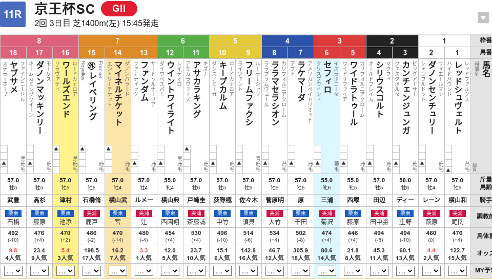

### 【ユニコーンステークス 2026/05/02(土) 】

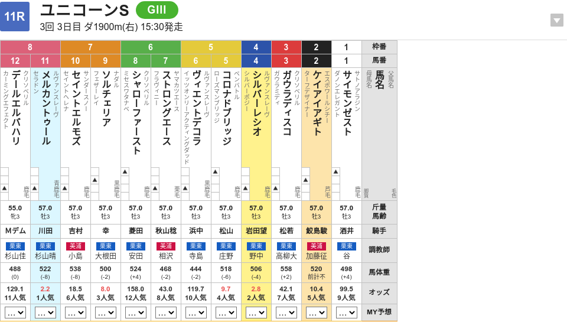

### 【天皇賞(春) 2026/05/03(日) 】

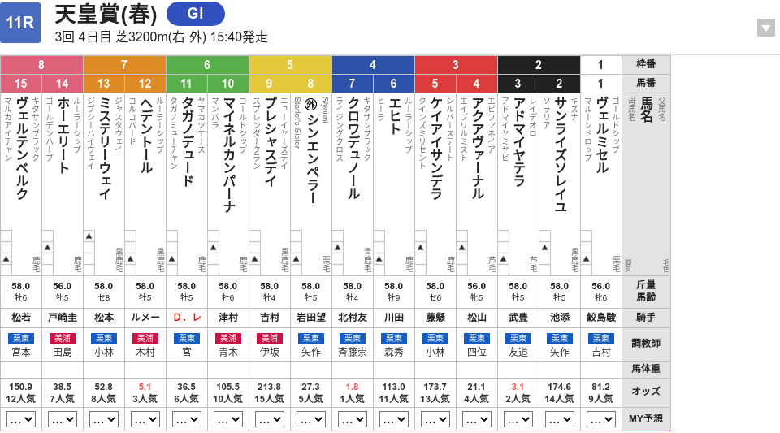

## 4. 単勝予測結果

### 【京王杯スプリングC(GⅡ) 2026/05/02(土)】

| 枠番 | 馬番 | 人気 | オッズ | 馬名 | 騎手 | 調教師 | 予測タイム(sec) | 1_順位 | 1-3着内確率(%) | 2_順位 | ﾀﾞｰｸﾎｰｽ確率(%) | 3_順位 |
| --- | --- | --- | --- | --- | --- | --- | --- | --- | --- | --- | --- | --- |
| 1 | 1 | 15 | 122.7 | レッドシュヴェルト | 横山和生 | 尾関知人 | 89.8 | 15 | 3.8 | 15 | 15.6 | 8 |
| 1 | 2 | 2 | 4.4 | ダノンセンチュリー | Ｄ．レーン | 萩原清 | 80.9 | 8 | 39.7 | 1 | 0.5 | 16 |
| 2 | 3 | 13 | 60.1 | カンチェンジュンガ | Ｍ．ディー | 庄野靖志 | 90.1 | 17 | 2.3 | 17 | 24.9 | 5 |
| 2 | 4 | 11 | 45.3 | シリウスコルト | 田辺裕信 | 田中勝春 | 81.0 | 9 | 6.7 | 12 | 35.2 | 3 |
| 3 | 5 | 8 | 21.8 | ワイドラトゥール | 西塚洸二 | 藤原英昭 | 80.0 | 3 | 15.6 | 7 | 1.2 | 11 |
| 3 | 6 | 14 | 80.6 | セフィロ | 三浦皇成 | 菊沢隆徳 | 80.0 | 4 | 5.6 | 13 | 43.2 | 2 |
| 4 | 7 | 18 | 305.9 | ラケマーダ | 原優介 | 千田輝彦 | 89.1 | 13 | 1.7 | 18 | 16.6 | 7 |
| 4 | 8 | 12 | 46.7 | ララマセラシオン | 菅原明良 | 大竹正博 | 89.3 | 14 | 2.3 | 16 | 12.2 | 9 |
| 5 | 9 | 16 | 142.8 | フリームファクシ | 佐々木大輔 | 須貝尚介 | 89.9 | 16 | 4.6 | 14 | 20.3 | 6 |
| 5 | 10 | 6 | 15.1 | キープカルム | 荻野極 | 中竹和也 | 83.3 | 11 | 27.9 | 3 | 1.3 | 10 |

[output cut: 8 more lines]

### 【ユニコーンステークス(GⅢ) 2026/05/02(土)】

| 枠番 | 馬番 | 人気 | オッズ | 馬名 | 騎手 | 調教師 | 予測タイム(sec) | 1_順位 | 1-3着内確率(%) | 2_順位 | ﾀﾞｰｸﾎｰｽ確率(%) | 3_順位 |
| --- | --- | --- | --- | --- | --- | --- | --- | --- | --- | --- | --- | --- |
| 1 | 1 | 9 | 99.5 | サイモンゼスト | 酒井学 | 谷潔 | 102.7 | 3 | 2.6 | 11 | 6.7 | 6 |
| 2 | 2 | 5 | 10.4 | ケイアイアギト | 鮫島克駿 | 加藤征弘 | 96.2 | 2 | 22.6 | 3 | 1.9 | 7 |
| 3 | 3 | 7 | 42.1 | ガウラディスコ | 松若風馬 | 高柳大輔 | 104.0 | 12 | 4.1 | 8 | 27.1 | 3 |
| 4 | 4 | 2 | 2.8 | シルバーレシオ | 岩田望来 | 野中賢二 | 103.1 | 6 | 49.9 | 1 | 0.4 | 11 |
| 5 | 5 | 4 | 9.7 | コロナドブリッジ | 松山弘平 | 庄野靖志 | 103.7 | 9 | 19.9 | 4 | 0.9 | 9 |
| 5 | 6 | 10 | 119.7 | ヴィエントデコラ | 浜中俊 | 寺島良 | 103.5 | 8 | 5.4 | 7 | 40.7 | 1 |
| 6 | 7 | 8 | 43.0 | ストロングエース | 秋山稔樹 | 相沢郁 | 102.7 | 4 | 2.8 | 10 | 9.3 | 5 |
| 6 | 8 | 12 | 158.0 | シャローファースト | 菱田裕二 | 安田翔伍 | 103.8 | 10 | 3.2 | 9 | 27.5 | 2 |
| 7 | 9 | 3 | 8.0 | ソルチェリア | 幸英明 | 大根田裕之 | 103.4 | 7 | 27.4 | 2 | 1.0 | 8 |
| 7 | 10 | 6 | 18.5 | セイントエルモズ | 吉村誠之助 | 小島茂之 | 102.8 | 5 | 11.9 | 6 | 0.8 | 10 |

[output cut: 2 more lines]

### 【天皇賞(春)(GⅠ) 2026/05/03(日)】

| 枠番 | 馬番 | 人気 | オッズ | 馬名 | 騎手 | 調教師 | 予測タイム(sec) | 1_順位 | 1-3着内確率(%) | 2_順位 | ﾀﾞｰｸﾎｰｽ確率(%) | 3_順位 |
| --- | --- | --- | --- | --- | --- | --- | --- | --- | --- | --- | --- | --- |
| 1 | 1 | 9 | 80.6 | ヴェルミセル | 鮫島克駿 | 吉村圭司 | 199.2 | 6.0 | 12.8 | 8 | 29.5 | 4 |
| 2 | 2 | 14 | 173.4 | サンライズソレイユ | 池添謙一 | 矢作芳人 | 198.8 | 5.0 | 7.5 | 11 | 50.5 | 3 |
| 2 | 3 | 2 | 3.2 | アドマイヤテラ | 武豊 | 友道康夫 | 195.5 | 2.0 | 21.1 | 4 | 0.5 | 15 |
| 3 | 4 | 4 | 21.2 | アクアヴァーナル | 松山弘平 | 四位洋文 | 198.7 | 4.0 | 16.6 | 5 | 1.2 | 12 |
| 3 | 5 | 13 | 169.5 | ケイアイサンデラ | 藤懸貴志 | 小林真也 | 204.1 | 14.0 | 3.6 | 15 | 29.1 | 5 |
| 4 | 6 | 11 | 113.4 | エヒト | 川田将雅 | 森秀行 | 199.9 | 9.0 | 4.1 | 14 | 21.6 | 7 |
| 4 | 7 | 1 | 1.8 | クロワデュノール | 北村友一 | 斉藤崇史 | 192.5 | 1.0 | 42.0 | 1 | 0.6 | 13 |
| 5 | 8 | 5 | 27.5 | シンエンペラー | 岩田望来 | 矢作芳人 | 199.7 | 8.0 | 28.2 | 3 | 1.4 | 9 |
| 5 | 9 | 15 | 213.2 | プレシャスデイ | 吉村誠之助 | 伊坂重信 | 202.3 | 12.0 | 8.8 | 10 | 55.8 | 1 |
| 6 | 10 | 10 | 105.5 | マイネルカンパーナ | 津村明秀 | 青木孝文 | 200.2 | 10.5 | 11.3 | 9 | 27.0 | 6 |

[output cut: 5 more lines]

## 5. 人気と着順の乖離率推移

### 【京王杯スプリングC_1990y_2019y】

[interactive chart not shown]

### 【ユニコーンステークス_1996y_2019y】

[interactive chart not shown]

### 【天皇賞_春_1990y_2019y】

[interactive chart not shown]

### 【京王杯スプリングC_1990y_2019y】

| No | 開催年 | 不整合率(%) | 頭数 | 人気別着順(1-3位) | 人気別着順(全体) |
| --- | --- | --- | --- | --- | --- |
| 30 | 2019 | 14.8 | 15頭 | 1-6-2 | 1\|6\|2\|3\|8\|12\|4\|9\|11\|14\|7\|5\|13\|10\|15 |
| 29 | 2018 | 54.6 | 18頭 | 4-7-2 | 4\|7\|2\|3\|14\|6\|11\|8\|17\|13\|15\|5\|10\|16\|1\|18\|9\|12 |
| 28 | 2017 | 43.5 | 13頭 | 2-11-4 | 2\|11\|4\|13\|6\|8\|5\|10\|1\|9\|3\|7\|12 |
| 27 | 2016 | 51.2 | 16頭 | 3-7-2 | 3\|7\|2\|4\|11\|5\|1\|9\|8\|6\|15\|12\|10\|14\|13\|16 |
| 26 | 2015 | 46.6 | 18頭 | 5-2-7 | 5\|2\|7\|10\|11\|3\|8\|16\|14\|1\|13\|4\|17\|9\|12\|6\|18\|15 |
| 25 | 2014 | 43.2 | 15頭 | 10-2-7 | 10\|2\|7\|8\|4\|5\|1\|12\|3\|9\|11\|6\|14\|13\|15 |
| 24 | 2013 | 32.3 | 18頭 | 1-5-6 | 1\|5\|6\|9\|15\|18\|3\|2\|10\|11\|7\|12\|4\|17\|14\|8\|13\|16 |
| 23 | 2012 | 49.4 | 15頭 | 4-11-13 | 4\|11\|13\|2\|7\|6\|5\|14\|12\|1\|3\|15\|10\|8\|9 |
| 22 | 2011 | 59.2 | 17頭 | 4-3-2 | 4\|3\|2\|13\|6\|9\|15\|5\|1\|12\|14\|7\|17\|8\|10\|11\|16 |
| 21 | 2010 | 49.0 | 17頭 | 10-5-3 | 10\|5\|3\|1\|7\|9\|13\|4\|15\|2\|6\|8\|12\|11\|14\|16\|17 |

[output cut: 20 more lines]

### 【ユニコーンステークス_1996y_2019y】

| No | 開催年 | 不整合率(%) | 頭数 | 人気別着順(1-3位) | 人気別着順(全体) |
| --- | --- | --- | --- | --- | --- |
| 24 | 2019 | 54.3 | 13頭 | 3-2-6 | 3\|2\|6\|8\|10\|9\|1\|12\|5\|7\|4\|13\|11 |
| 23 | 2018 | 32.8 | 16頭 | 1-3-7 | 1\|3\|7\|10\|16\|13\|6\|5\|2\|8\|14\|11\|4\|9\|15\|12 |
| 22 | 2017 | 43.6 | 16頭 | 2-5-3 | 2\|5\|3\|9\|11\|7\|1\|4\|10\|8\|14\|13\|6\|16\|15\|12 |
| 21 | 2016 | 19.8 | 16頭 | 2-1-3 | 2\|1\|3\|6\|5\|4\|9\|7\|8\|15\|12\|11\|14\|10\|13\|16 |
| 20 | 2015 | 36.9 | 16頭 | 2-9-3 | 2\|9\|3\|1\|5\|10\|16\|15\|12\|7\|8\|4\|6\|14\|13\|11 |
| 19 | 2014 | 64.6 | 16頭 | 3-4-7 | 3\|4\|7\|6\|11\|5\|15\|13\|2\|10\|9\|1\|8\|12\|14\|16 |
| 18 | 2013 | 40.8 | 15頭 | 3-1-8 | 3\|1\|8\|11\|12\|6\|9\|2\|10\|4\|15\|7\|5\|13\|14 |
| 17 | 2012 | 15.4 | 16頭 | 1-2-8 | 1\|2\|8\|5\|13\|3\|11\|10\|15\|16\|4\|6\|12\|7\|14\|9 |
| 16 | 2011 | 34.6 | 16頭 | 3-1-2 | 3\|1\|2\|15\|8\|12\|6\|9\|4\|10\|16\|11\|5\|7\|14\|13 |
| 15 | 2010 | 12.8 | 15頭 | 1-2-6 | 1\|2\|6\|3\|10\|8\|9\|16\|5\|7\|11\|14\|12\|15\|13 |

[output cut: 14 more lines]

### 【天皇賞_春_1990y_2019y】

| No | 開催年 | 不整合率(%) | 頭数 | 人気別着順(1-3位) | 人気別着順(全体) |
| --- | --- | --- | --- | --- | --- |
| 30 | 2019 | 15.2 | 12頭 | 1-6-8 | 1\|6\|8\|2\|3\|10\|9\|11\|13\|4\|5\|7 |
| 29 | 2018 | 34.2 | 17頭 | 2-1-4 | 2\|1\|4\|9\|7\|8\|12\|6\|14\|11\|17\|5\|13\|3\|16\|10\|15 |
| 28 | 2017 | 23.5 | 17頭 | 1-4-2 | 1\|4\|2\|10\|6\|8\|5\|9\|3\|15\|11\|7\|14\|16\|12\|17\|13 |
| 27 | 2016 | 45.7 | 18頭 | 2-13-3 | 2\|13\|3\|10\|7\|6\|16\|4\|11\|8\|12\|1\|9\|15\|5\|18\|17\|14 |
| 26 | 2015 | 41.6 | 17頭 | 2-7-10 | 2\|7\|10\|5\|16\|11\|1\|8\|4\|9\|14\|6\|17\|15\|3\|12\|13 |
| 25 | 2014 | 47.2 | 18頭 | 4-3-12 | 4\|3\|12\|1\|13\|11\|2\|6\|7\|18\|8\|14\|10\|9\|16\|17\|5\|15 |
| 24 | 2013 | 37.3 | 18頭 | 2-3-6 | 2\|3\|6\|4\|1\|8\|11\|14\|5\|10\|16\|13\|15\|17\|9\|7\|18\|12 |
| 23 | 2012 | 51.6 | 18頭 | 14-3-2 | 14\|3\|2\|9\|4\|13\|10\|17\|8\|16\|5\|1\|11\|15\|6\|12\|18\|7 |
| 22 | 2011 | 69.0 | 17頭 | 7-3-5 | 7\|3\|5\|17\|18\|6\|9\|4\|8\|12\|2\|16\|1\|13\|11\|14\|15 |
| 21 | 2010 | 31.4 | 18頭 | 2-4-16 | 2\|4\|16\|7\|12\|1\|3\|17\|6\|5\|8\|13\|18\|11\|14\|15\|9\|10 |

[output cut: 20 more lines]

## 6. 1-3番人気馬の着順分類予測

### 【京王杯スプリングC】

| 分類 | 凡例 | 発生確率(%) | 当該レース | 当該レースランク | 直近1年間 |
| --- | --- | --- | --- | --- | --- |
| 4: 1,2番人気のみ (4_pop12) | 1 \| 2 \| * | 20.2 | 0.61 | 0.61 | 0.61 |
| 1: 1番人気のみ (1_pop1) | 1 \| * \| * | 18.1 | 2.18 | 2.18 | 0.54 |
| 5: 1,3番人気のみ (5_pop13) | 1 \| 3 \| * | 13.7 | 4.89 | 4.89 | 0.00 |
| 8: 1,2,3番人気すべて着外 (8_darkhorse) | * \| * \| * | 13.5 | 0.81 | 0.81 | 0.00 |
| 2: 2番人気のみ (2_pop2) | 2 \| * \| * | 9.6 | 0.49 | 0.49 | 0.00 |
| 6: 2,3番人気のみ (6_pop23) | 2 \| 3 \| * | 9.1 | 0.82 | 0.82 | 0.27 |
| 3: 3番人気のみ (3_pop3) | 3 \| * \| * | 8.4 | 1.01 | 1.01 | 0.00 |
| 7: 1,2,3番人気すべて着内 (7_pop123) | 1 \| 2 \| 3 | 7.2 | 0.00 | 0.00 | 0.00 |

### 【ユニコーンステークス】

| 分類 | 凡例 | 発生確率(%) | 当該レース | 当該レースランク | 直近1年間 |
| --- | --- | --- | --- | --- | --- |
| 1: 1番人気のみ (1_pop1) | 1 \| * \| * | 17.6 | 0.00 | 0.00 | 0.53 |
| 4: 1,2番人気のみ (4_pop12) | 1 \| 2 \| * | 17.6 | 1.05 | 1.05 | 0.53 |
| 8: 1,2,3番人気すべて着外 (8_darkhorse) | * \| * \| * | 13.8 | 2.06 | 2.06 | 0.00 |
| 6: 2,3番人気のみ (6_pop23) | 2 \| 3 \| * | 13.5 | 0.34 | 0.34 | 0.41 |
| 5: 1,3番人気のみ (5_pop13) | 1 \| 3 \| * | 13.2 | 0.79 | 0.79 | 0.00 |
| 2: 2番人気のみ (2_pop2) | 2 \| * \| * | 9.0 | 1.34 | 1.34 | 0.00 |
| 3: 3番人気のみ (3_pop3) | 3 \| * \| * | 8.3 | 2.52 | 2.52 | 0.00 |
| 7: 1,2,3番人気すべて着内 (7_pop123) | 1 \| 2 \| 3 | 7.0 | 0.70 | 0.70 | 0.00 |

### 【天皇賞(春)】

| 分類 | 凡例 | 発生確率(%) | 当該レース | 当該レースランク | 直近1年間 |
| --- | --- | --- | --- | --- | --- |
| 4: 1,2番人気のみ (4_pop12) | 1 \| 2 \| * | 20.2 | 1.45 | 1.45 | 0.00 |
| 1: 1番人気のみ (1_pop1) | 1 \| * \| * | 18.1 | 0.72 | 0.72 | 0.18 |
| 5: 1,3番人気のみ (5_pop13) | 1 \| 3 \| * | 13.7 | 4.89 | 4.89 | 0.00 |
| 8: 1,2,3番人気すべて着外 (8_darkhorse) | * \| * \| * | 13.5 | 1.63 | 1.63 | 0.00 |
| 2: 2番人気のみ (2_pop2) | 2 \| * \| * | 9.6 | 0.86 | 0.86 | 0.00 |
| 6: 2,3番人気のみ (6_pop23) | 2 \| 3 \| * | 9.1 | 0.82 | 0.82 | 0.00 |
| 3: 3番人気のみ (3_pop3) | 3 \| * \| * | 8.4 | 1.01 | 1.01 | 0.00 |
| 7: 1,2,3番人気すべて着内 (7_pop123) | 1 \| 2 \| 3 | 7.2 | 0.37 | 0.37 | 0.00 |

## 7. 3連複予測結果

### 【京王杯スプリングC(GⅡ) 2026/05/02(土)】

| 分類 | 馬番 | 枠番 | 人気 | 平均予測タイム(sec) | 1-3着内確率(%) | ﾀﾞｰｸﾎｰｽ確率(%) | 馬名 | 騎手 | 調教師 |
| --- | --- | --- | --- | --- | --- | --- | --- | --- | --- |
| 6: 2,3番人気のみ (6_pop23) | 2-16-10 | 1-8-5 | 2-3-6 | 81.37 | 3.47 | 0.00 | ダノンセンチュリー \| ワールズエンド \| キープカルム | Ｄ．レーン \| 津村明秀 \| 荻野極 | 萩原清 \| 池添学 \| 中竹和也 |
| 6: 2,3番人気のみ (6_pop23) | 2-16-18 | 1-8-8 | 2-3-4 | 80.53 | 3.22 | 0.00 | ダノンセンチュリー \| ワールズエンド \| ヤブサメ | Ｄ．レーン \| 津村明秀 \| 武豊 | 萩原清 \| 池添学 \| 石橋守 |
| 6: 2,3番人気のみ (6_pop23) | 2-16-14 | 1-8-7 | 2-3-7 | 81.17 | 3.14 | 0.00 | ダノンセンチュリー \| ワールズエンド \| マイネルチケット | Ｄ．レーン \| 津村明秀 \| 横山武史 | 萩原清 \| 池添学 \| 宮徹 |
| 6: 2,3番人気のみ (6_pop23) | 2-16-12 | 1-8-6 | 2-3-5 | 80.27 | 3.04 | 0.00 | ダノンセンチュリー \| ワールズエンド \| ウイントワイライト | Ｄ．レーン \| 津村明秀 \| 横山典弘 | 萩原清 \| 池添学 \| 西園翔太 |
| 2: 2番人気のみ (2_pop2) | 2-18-10 | 1-8-5 | 2-4-6 | 81.67 | 2.87 | 0.00 | ダノンセンチュリー \| ヤブサメ \| キープカルム | Ｄ．レーン \| 武豊 \| 荻野極 | 萩原清 \| 石橋守 \| 中竹和也 |
| 2: 2番人気のみ (2_pop2) | 2-10-14 | 1-5-7 | 2-6-7 | 82.30 | 2.80 | 0.00 | ダノンセンチュリー \| キープカルム \| マイネルチケット | Ｄ．レーン \| 荻野極 \| 横山武史 | 萩原清 \| 中竹和也 \| 宮徹 |
| 2: 2番人気のみ (2_pop2) | 2-12-10 | 1-6-5 | 2-5-6 | 81.40 | 2.71 | 0.00 | ダノンセンチュリー \| ウイントワイライト \| キープカルム | Ｄ．レーン \| 横山典弘 \| 荻野極 | 萩原清 \| 西園翔太 \| 中竹和也 |
| 2: 2番人気のみ (2_pop2) | 2-18-14 | 1-8-7 | 2-4-7 | 81.47 | 2.59 | 0.00 | ダノンセンチュリー \| ヤブサメ \| マイネルチケット | Ｄ．レーン \| 武豊 \| 横山武史 | 萩原清 \| 石橋守 \| 宮徹 |
| 2: 2番人気のみ (2_pop2) | 2-18-12 | 1-8-6 | 2-4-5 | 80.57 | 2.52 | 0.00 | ダノンセンチュリー \| ヤブサメ \| ウイントワイライト | Ｄ．レーン \| 武豊 \| 横山典弘 | 萩原清 \| 石橋守 \| 西園翔太 |
| 2: 2番人気のみ (2_pop2) | 2-12-14 | 1-6-7 | 2-5-7 | 81.20 | 2.46 | 0.00 | ダノンセンチュリー \| ウイントワイライト \| マイネルチケット | Ｄ．レーン \| 横山典弘 \| 横山武史 | 萩原清 \| 西園翔太 \| 宮徹 |

[output cut: 806 more lines]

### 【ユニコーンステークス(GⅢ) 2026/05/02(土)】

| 分類 | 馬番 | 枠番 | 人気 | 平均予測タイム(sec) | 1-3着内確率(%) | ﾀﾞｰｸﾎｰｽ確率(%) | 馬名 | 騎手 | 調教師 |
| --- | --- | --- | --- | --- | --- | --- | --- | --- | --- |
| 6: 2,3番人気のみ (6_pop23) | 4-9-2 | 4-7-2 | 2-3-5 | 100.90 | 3.08 | 0.00 | シルバーレシオ \| ソルチェリア \| ケイアイアギト | 岩田望来 \| 幸英明 \| 鮫島克駿 | 野中賢二 \| 大根田裕之 \| 加藤征弘 |
| 6: 2,3番人気のみ (6_pop23) | 4-9-5 | 4-7-5 | 2-3-4 | 103.40 | 2.71 | 0.00 | シルバーレシオ \| ソルチェリア \| コロナドブリッジ | 岩田望来 \| 幸英明 \| 松山弘平 | 野中賢二 \| 大根田裕之 \| 庄野靖志 |
| 2: 2番人気のみ (2_pop2) | 4-5-2 | 4-5-2 | 2-4-5 | 101.00 | 2.24 | 0.00 | シルバーレシオ \| コロナドブリッジ \| ケイアイアギト | 岩田望来 \| 松山弘平 \| 鮫島克駿 | 野中賢二 \| 庄野靖志 \| 加藤征弘 |
| 7: 1,2,3番人気すべて着内 (7_pop123) | 11-4-9 | 8-4-7 | 1-2-3 | 100.50 | 2.23 | 0.00 | メルカントゥール \| シルバーレシオ \| ソルチェリア | 川田将雅 \| 岩田望来 \| 幸英明 | 杉山晴紀 \| 野中賢二 \| 大根田裕之 |
| 4: 1,2番人気のみ (4_pop12) | 11-4-2 | 8-4-2 | 1-2-5 | 98.10 | 1.84 | 0.00 | メルカントゥール \| シルバーレシオ \| ケイアイアギト | 川田将雅 \| 岩田望来 \| 鮫島克駿 | 杉山晴紀 \| 野中賢二 \| 加藤征弘 |
| 4: 1,2番人気のみ (4_pop12) | 11-4-5 | 8-4-5 | 1-2-4 | 100.60 | 1.62 | 0.00 | メルカントゥール \| シルバーレシオ \| コロナドブリッジ | 川田将雅 \| 岩田望来 \| 松山弘平 | 杉山晴紀 \| 野中賢二 \| 庄野靖志 |
| 6: 2,3番人気のみ (6_pop23) | 4-9-10 | 4-7-7 | 2-3-6 | 103.10 | 1.62 | 0.00 | シルバーレシオ \| ソルチェリア \| セイントエルモズ | 岩田望来 \| 幸英明 \| 吉村誠之助 | 野中賢二 \| 大根田裕之 \| 小島茂之 |
| 2: 2番人気のみ (2_pop2) | 4-2-10 | 4-2-7 | 2-5-6 | 100.70 | 1.34 | 0.00 | シルバーレシオ \| ケイアイアギト \| セイントエルモズ | 岩田望来 \| 鮫島克駿 \| 吉村誠之助 | 野中賢二 \| 加藤征弘 \| 小島茂之 |
| 3: 3番人気のみ (3_pop3) | 9-5-2 | 7-5-2 | 3-4-5 | 101.10 | 1.23 | 0.00 | ソルチェリア \| コロナドブリッジ \| ケイアイアギト | 幸英明 \| 松山弘平 \| 鮫島克駿 | 大根田裕之 \| 庄野靖志 \| 加藤征弘 |
| 2: 2番人気のみ (2_pop2) | 4-5-10 | 4-5-7 | 2-4-6 | 103.20 | 1.18 | 0.00 | シルバーレシオ \| コロナドブリッジ \| セイントエルモズ | 岩田望来 \| 松山弘平 \| 吉村誠之助 | 野中賢二 \| 庄野靖志 \| 小島茂之 |

[output cut: 210 more lines]

### 【天皇賞(春)(GⅠ) 2026/05/03(日)】

| 分類 | 馬番 | 枠番 | 人気 | 平均予測タイム(sec) | 1-3着内確率(%) | ﾀﾞｰｸﾎｰｽ確率(%) | 馬名 | 騎手 | 調教師 |
| --- | --- | --- | --- | --- | --- | --- | --- | --- | --- |
| 5: 1,3番人気のみ (5_pop13) | 7-12-8 | 4-7-5 | 1-3-5 | 196.57 | 4.13 | 0.00 | クロワデュノール \| ヘデントール \| シンエンペラー | 北村友一 \| Ｃ．ルメール \| 岩田望来 | 斉藤崇史 \| 木村哲也 \| 矢作芳人 |
| 7: 1,2,3番人気すべて着内 (7_pop123) | 7-3-12 | 4-2-7 | 1-2-3 | 195.17 | 3.09 | 0.00 | クロワデュノール \| アドマイヤテラ \| ヘデントール | 北村友一 \| 武豊 \| Ｃ．ルメール | 斉藤崇史 \| 友道康夫 \| 木村哲也 |
| 4: 1,2番人気のみ (4_pop12) | 7-3-8 | 4-2-5 | 1-2-5 | 195.90 | 2.50 | 0.00 | クロワデュノール \| アドマイヤテラ \| シンエンペラー | 北村友一 \| 武豊 \| 岩田望来 | 斉藤崇史 \| 友道康夫 \| 矢作芳人 |
| 5: 1,3番人気のみ (5_pop13) | 7-12-4 | 4-7-3 | 1-3-4 | 196.23 | 2.43 | 0.00 | クロワデュノール \| ヘデントール \| アクアヴァーナル | 北村友一 \| Ｃ．ルメール \| 松山弘平 | 斉藤崇史 \| 木村哲也 \| 四位洋文 |
| 5: 1,3番人気のみ (5_pop13) | 7-12-11 | 4-7-6 | 1-3-6 | 196.73 | 2.42 | 0.00 | クロワデュノール \| ヘデントール \| タガノデュード | 北村友一 \| Ｃ．ルメール \| Ｄ．レーン | 斉藤崇史 \| 木村哲也 \| 宮徹 |
| 5: 1,3番人気のみ (5_pop13) | 7-12-14 | 4-7-8 | 1-3-7 | 197.53 | 2.12 | 0.00 | クロワデュノール \| ヘデントール \| ホーエリート | 北村友一 \| Ｃ．ルメール \| 戸崎圭太 | 斉藤崇史 \| 木村哲也 \| 田島俊明 |
| 6: 2,3番人気のみ (6_pop23) | 3-12-8 | 2-7-5 | 2-3-5 | 197.57 | 2.08 | 0.00 | アドマイヤテラ \| ヘデントール \| シンエンペラー | 武豊 \| Ｃ．ルメール \| 岩田望来 | 友道康夫 \| 木村哲也 \| 矢作芳人 |
| 1: 1番人気のみ (1_pop1) | 7-4-8 | 4-3-5 | 1-4-5 | 196.97 | 1.97 | 0.00 | クロワデュノール \| アクアヴァーナル \| シンエンペラー | 北村友一 \| 松山弘平 \| 岩田望来 | 斉藤崇史 \| 四位洋文 \| 矢作芳人 |
| 1: 1番人気のみ (1_pop1) | 7-8-11 | 4-5-6 | 1-5-6 | 197.47 | 1.96 | 0.00 | クロワデュノール \| シンエンペラー \| タガノデュード | 北村友一 \| 岩田望来 \| Ｄ．レーン | 斉藤崇史 \| 矢作芳人 \| 宮徹 |
| 5: 1,3番人気のみ (5_pop13) | 7-12-1 | 4-7-1 | 1-3-9 | 196.40 | 1.87 | 0.00 | クロワデュノール \| ヘデントール \| ヴェルミセル | 北村友一 \| Ｃ．ルメール \| 鮫島克駿 | 斉藤崇史 \| 木村哲也 \| 吉村圭司 |

[output cut: 445 more lines]

## 8. 直近の全レース情報

[output not shown]

[output cut: 10 more lines]